# Artesanía Textil

Elizabeth Guadalupe Benítez Sotero

22 de marzo de 2021

Las artesanías textiles en México tienen una importancia relevante, no solo porque representan el mestizaje, las culturas, tradiciones y cosmogonías culturales, sino también porque son una actividad económica en donde participan miles de mujeres en todo el país. Muchas de las prendas que se producen son elaboradas con lana, algodón y seda tejidas mediante el uso del telar de cintura y bordadas a mano utilizando hilos teñidos con tintes naturales de varios colores derivados de flores, plantas o minerales. (Hernández, 2021)

Para las mujeres que participan en la elaboración de este tipo de artesanías significan elementos distintivos de la población indigena a la que pertenecen, en algunas ocasiones estampan motivos de su entorno físico, expresando su propia cosmogonía. Ellas no reconocen otra forma de vestir y, aunque tienen un gran valor simbólico y satisface sus necesidades básicas, las mujeres de estas comunidades han tenido que comercializar con ellas para generar ingresos que les ayuden a mantener a sus familias.

Sin embargo, en años recientes diversos grupos de diseñadores han encontrado en la colaboración con artesanos no sólo una manera de generar productos originales y de impecable calidad sino también la oportunidad de adquirir conocimiento y formar nuevas empresas culturales y creativas, las cuales abrevan de la tradición y dan como resultado objetos con identidad propia. Un ejemplo de esto es Hilos y entramados. Prácticas colaborativas en el diseño mexicano que reúne el trabajo de 37 diseñadores y colectivos que, a su vez, trabajan con 42 comunidades artesanales en 13 estados del país. (Secretaría de Cultura, 2016)

Estimular el comercio de las artesanías textiles ha provocado que a nivel internacional el trabajo mexicano sea valorado y hoy cuente con un gran reconocimiento por ser productos que manifiestan la diversidad cultural de una sociedad, lo que ha permitido al sector convertirse en un atractivo mercado con potencial de crecimiento. Datos de ProMéxico muestran que los principales destinos de exportación de las artesanías mexicanas son Australia, Alemania, Canadá, Colombia, España, Estados Unidos e Italia. (Forbes México, 2014)

Pero, la imitación de modas y costumbres ajenas, la introducción de materiales foráneos, el afán por lo novedoso y masivo, el desconocimiento o poca valoración de lo propio, hace desaparecer lo auténtico. (González, 2005) Además de los graves casos de plagio que se han presentado a nivel internacional.

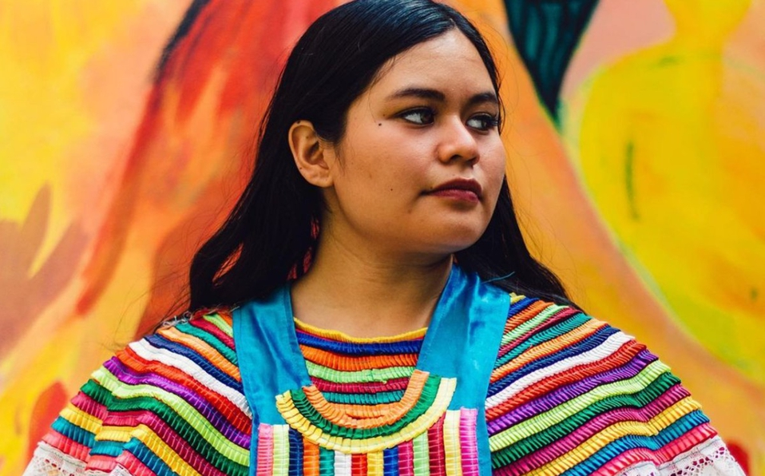

Fuente: Milenio (2021). ¡Todos venden por internet! Se viraliza lista de artesanos textiles mexicanos. Recuperado de:https://www.milenio.com/virales/se-viraliza-lista-de-artesanos-textiles-mexicanos

## Bibliografía

1. Forbes México. (2014). México y sus artesanías en el mundo. Recuperado de: https://www.forbes.com.mx/mexico-y-sus-artesanias-en-el-mundo/
2. González Eliçabe, Ximena.(2005). Arte, diseño y artesanía. La metáfora textil como signo de identidad. Reflexión Académica en Diseño y Comunicación Nº VI. Recuperado de: https://fido.palermo.edu/servicios_dyc/publicacionesdc/vista/detalle_articulo.php?id_libro=121&id_articulo=683
3. Hernández, José Ignacio. (2021). Conoce el origen de la artesanía textil mexicana. Recuperado de: https://blog.xcaret.com/es/artesania-textil-mexicana/
4. Secretaría de Cultura. (2016). Hilos y Entramados. Recuperado de: https://www.cultura.gob.mx/turismocultural/hilosyentramados/index.html